# House Selling Prices

2025-02-05

```r
pacman::p_load(tidyverse, ggplot2, ggthemes, DT, pander, car, mosaic, ggrepel)
```

```r
train <- read.csv('../../data/house_selling_prices_data/train.csv', stringsAsFactors = TRUE)
```

# Background

The aim of this analysis will be to build a regression model that can accurately predict the sale price of a given home. The model will be considered adequately accurate when it can achieve an adjusted R-squared value of $0.86$ and a validation adjusted R-squared value of $0.83$.

# Data

The data was provided through an online kaggle competition that can be found at [this link.](https://www.kaggle.com/c/house-prices-advanced-regression-techniques)

The data required significant cleaning and feature engineering in order to be suitable for an effective regression model. The process of cleaning and feature engineering can be seen below under the **Show Data Preprocessing** tab.

## Show Data Preprocessing

```r
colSums(is.na(train)) %>%
  .[. > 0]
```

```
##  LotFrontage        Alley   MasVnrType   MasVnrArea     BsmtQual     BsmtCond
##          259         1369            8            8           37           37
## BsmtExposure BsmtFinType1 BsmtFinType2   Electrical  FireplaceQu   GarageType
##           38           37           38            1          690           81
##  GarageYrBlt GarageFinish   GarageQual   GarageCond       PoolQC        Fence
##           81           81           81           81         1453         1179
##  MiscFeature
##         1406
```

```r
# we will do a lot of mutating this week
train <- train %>%

  #fix NA in alley
  mutate(
    Alley = as.character(Alley),
    Alley = replace_na(Alley, 'None'),
    Alley = as.factor(Alley)
  ) %>%

  #fix None in MasVnr Type
  mutate(
    MasVnrType = as.character(MasVnrType),
    MasVnrType = replace(MasVnrType, (MasVnrType == 'None') | is.na(MasVnrType), 'NoVNR'),
    MasVnrType = as.factor(MasVnrType)
  ) %>%

  # fix basement stuff
  mutate(
    BsmtQual = as.character(BsmtQual),
    BsmtQual = replace_na(BsmtQual, 'Nb'),
    BsmtQual = as.factor(BsmtQual),

    BsmtCond = as.character(BsmtCond),
    BsmtCond = replace_na(BsmtCond, 'Nb'),
    BsmtCond = as.factor(BsmtCond),

    BsmtExposure = as.character(BsmtExposure),
    BsmtExposure = replace_na(BsmtExposure, 'Nb'),
    BsmtExposure = as.factor(BsmtExposure),

    BsmtFinType1 = as.character(BsmtFinType1),
    BsmtFinType1 = replace_na(BsmtFinType1, 'Nb'),
    BsmtFinType1 = as.factor(BsmtFinType1),

    BsmtFinType2 = as.character(BsmtFinType2),
    BsmtFinType2 = replace_na(BsmtFinType2, 'Nb'),
    BsmtFinType2 = as.factor(BsmtFinType2)
  ) %>%

  #fix electrical
  mutate(
    Electrical = as.character(Electrical),
    Electrical = replace_na(Electrical, 'NoElec'),
  ) %>%

  # fix Fireplacequal
  mutate(
    FireplaceQu = as.character(FireplaceQu),
    FireplaceQu = replace_na(FireplaceQu, 'NoFP'),
    FireplaceQu = as.factor(FireplaceQu)
  ) %>%

  # fix garage stuff
  mutate(
    GarageType = as.character(GarageType),
    GarageType = replace_na(GarageType, 'NoGar'),
    GarageType = as.factor(GarageType),

    GarageFinish = as.character(GarageFinish),
    GarageFinish = replace_na(GarageFinish, 'NoGar'),
    GarageFinish = as.factor(GarageFinish),

    GarageQual = as.character(GarageQual),
    GarageQual = replace_na(GarageQual, 'NoGar'),
    GarageQual = as.factor(GarageQual),

    GarageCond = as.character(GarageCond),
    GarageCond = replace_na(GarageCond, 'NoGar'),
    GarageCond = as.factor(GarageCond)

  ) %>%

  #fix poolqc
  mutate(
    PoolQC = as.character(PoolQC),
    PoolQC = replace_na(PoolQC, 'NoPool'),
    PoolQC = as.factor(PoolQC)
  ) %>%

  # fix fence
  mutate(
    Fence = as.character(Fence),
    Fence = replace_na(Fence, 'NoFence'),
    Fence = as.factor(Fence)
  ) %>%

  # MiscFeature
  mutate(
    MiscFeature = as.character(MiscFeature),
    MiscFeature = replace_na(MiscFeature, 'NoMiscFt'),
    MiscFeature = as.factor(MiscFeature)
  )
```

# Technical Specifications

## Show Tech Specs

### Base Feature Importance

I found that the pandas, numpy, and XGBoost python libraries provided ways in which to build regression models without some of the limitations found in the simple mylm <- lm(…) function found in r. I decided to first build a regression model using XGBoost, without modifying the data, to provide a baseline of feature importances in predicting the sale price of a home. The following is the code that I built:

```python
!pip install scikit-learn==1.5.2

from xgboost import XGBRegressor
import sklearn
from sklearn.model_selection import train_test_split
from sklearn.metrics import mean_squared_error, r2_score, root_mean_squared_error
import pandas as pd
import numpy as np
import matplotlib.pyplot as plt

train = pd.read_csv('train.csv')

# Fix NA in Alley
train['Alley'] = train['Alley'].astype(str)
train['Alley'] = train['Alley'].fillna('None')
train['Alley'] = train['Alley'].astype('category')

# Fix None in MasVnrType
train['MasVnrType'] = train['MasVnrType'].astype(str)
train.loc[(train['MasVnrType'] == 'None') | (train['MasVnrType'] == 'nan'), 'MasVnrType'] = 'NoVNR'
train['MasVnrType'] = train['MasVnrType'].astype('category')

# Fix basement stuff
basement_cols = ['BsmtQual', 'BsmtCond', 'BsmtExposure', 'BsmtFinType1', 'BsmtFinType2']
for col in basement_cols:
    train[col] = train[col].astype(str)
    train[col] = train[col].fillna('Nb')
    train[col] = train[col].astype('category')

# Fix electrical
train['Electrical'] = train['Electrical'].astype(str)
train['Electrical'] = train['Electrical'].fillna('NoElec')

# Fix FireplaceQu
train['FireplaceQu'] = train['FireplaceQu'].astype(str)
train['FireplaceQu'] = train['FireplaceQu'].fillna('NoFP')
train['FireplaceQu'] = train['FireplaceQu'].astype('category')

# Fix garage stuff
garage_cols = ['GarageType', 'GarageFinish', 'GarageQual', 'GarageCond']
for col in garage_cols:
    train[col] = train[col].astype(str)
    train[col] = train[col].fillna('NoGar')
    train[col] = train[col].astype('category')

# Fix PoolQC
train['PoolQC'] = train['PoolQC'].astype(str)
train['PoolQC'] = train['PoolQC'].fillna('NoPool')
train['PoolQC'] = train['PoolQC'].astype('category')

# Fix Fence
train['Fence'] = train['Fence'].astype(str)
train['Fence'] = train['Fence'].fillna('NoFence')
train['Fence'] = train['Fence'].astype('category')

# Fix MiscFeature
train['MiscFeature'] = train['MiscFeature'].astype(str)
train['MiscFeature'] = train['MiscFeature'].fillna('NoMiscFt')
train['MiscFeature'] = train['MiscFeature'].astype('category')


# make remaining objects into categories
obj_cols = train.select_dtypes(include = ['object']).columns
for col in obj_cols:
  train[col] = train[col].astype('category')
```

The code above shows the python version of the initial mutate statements that can be found in the **Data** section of this analysis.

The following code splits the data, creates an instance of a regression, and then fits the model to the data

```python
# target variables
X = train.drop(columns = ['SalePrice'])
y = train['SalePrice']

X_train, X_test, y_train, y_test = train_test_split(X, y, test_size=0.2, random_state=42)
# regressor
model = XGBRegressor(enable_categorical = True)
model.fit(X_train, y_train)
```

I then used the fitted model to make predictions on the test data that was held out in `the train_test_split()` function.

```python
pred = model.predict(X_test)
pred
```

I then used sklearn’s metric library to calculate metrics for the performance of the model.

```python
r2_score(y_test, pred)
root_mean_squared_error(y_test, pred)
```

This model produced an R-squared score of $0.9117$ and a root mean squared error of $26,027.22$ meaning that it captured about $91\%$ of the data’s variance and was off in predictions by about $\$26,027.22$

I then used the following code to calculate feature importances, meaning how much each feature contributed to the model’s predictions. I plotted the 10 most important features.

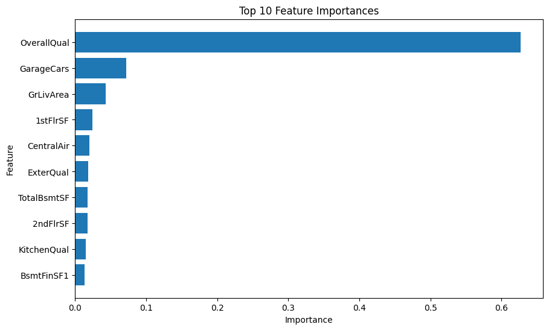

```python
# Get feature importances
feature_importances = model.feature_importances_

# Create a DataFrame for easier handling
feature_importance_df = pd.DataFrame({'Feature': X_train.columns, 'Importance': feature_importances})

# Sort by importance
feature_importance_df = feature_importance_df.sort_values(by='Importance', ascending=False)

# Get the top 10 features
top_10_features = feature_importance_df.head(10)

# Create the plot
plt.figure(figsize=(10, 6))
plt.barh(top_10_features['Feature'], top_10_features['Importance'])
plt.xlabel('Importance')
plt.ylabel('Feature')
plt.title('Top 10 Feature Importances')
plt.gca().invert_yaxis()  # Invert y-axis to show most important at the top
plt.show()
```

The chart above shows that `OverallQual` is far and away the most important feature in this particular model for predicting home sale prices. It should be noted that this model assumes no data processing aside from clarifying the existing NA cases. There have been no transformations, interactions, or mutations added to the data. This method simply allowed me to look at potentially important features without leaving any one feature out. I now feel more comfortable selecting which features to include in the final model. Further, I feel comfortable adding my own interactions and creating columns that can capture intricacies in the data that might be hidden from the initial versions of the model.

### Feature Exploration and Mutation

As demonstrated in class, the total square footage of a house and whether or not it is in a rich neighborhood are powerful engineered features in predicting the sale price of a home.

```r
train <- train %>%
  mutate(
    TotalSF = X1stFlrSF + X2ndFlrSF + TotalBsmtSF,
    RichNbrhd = case_when(
      Neighborhood %in% c("StoneBr", "NridgHt", "NoRidge") ~ 1,
      TRUE ~ 0
    )
  )
```

#### Other Potentially Important Features From Baseline Model

- `GarageCars`
  - The number of cars that can fit in the garage of a home.
- `GrLivArea`
  - The above grade living area of a home in square feet
- `CentralAir`
  - A boolean representing whether or not the home has a centralized air conditioning system.
  - A HVAC system in a home, though complicated, is highly preferred over other types of home climate control like in-window units and ductless mini-split systems.It is expected that a true case of central air will increase the predicted sale price of a given home.
- `KitchenQual`
  - A measure of the quality of a home’s kitchen including poor, fair, typical/average, good, and excellent.
- `KitchenAbvGr`
  - The number of kitchens above grade in a home.
  - This feature was not specifically highlighted in the feature importance graph, but is highly linked to the `KitchenQual` feature. I will include it in early stages of my final model, with it’s appearance in the final model being dependent on its significance as measured by the p-value.
- `MoSold`, `YrSold`, and `SaleType`
  - I am including these features in an effort to capture information based on the time and type of sale. My reasoning lies in the fact that the data spans the Subprime Mortage Crisis. I hope that the inclusion of time based features will help my model generalize to other validation dataset in which market trends do not mirror those of this period of time.

### Model Construction

#### Insignificant Features (excluded from final model)

- `MoSold`
- `YrSold`

#### Engineered Features

- `NewConst`
  - A boolean representing whether or not the sale is new construction.
- `HasPool`
  - A boolean representing whether or not the home has a pool.
- `RichQual`
  - Multiply `RichNbrhd` by `OverallQual`
- `RichGrLivArea`
  - Multiply `RichNbrhd` by `GrLivArea`
- `OverallQualPool`
  - Multiply `OverallQual` by `HasPool`

```r
train <- train %>%
  mutate(
    NewConst = case_when(
      SaleType == 'New' ~ 1,
      TRUE ~ 0
    ),
    WDSale = case_when(
      SaleType == 'WD' ~ 1,
      TRUE ~ 0
    ),
    FifteenDown = case_when(
      SaleType == 'Con' ~ 1,
      TRUE ~ 0
    ),
    HasPool = case_when(
      PoolArea > 0 ~ 1,
      TRUE ~ 0
    ),
    HasGarage = case_when(
      GarageQual == 'NoGar' ~ 0,
      TRUE ~ 1
    ),
    GoodKitchen = case_when(
      KitchenQual  %in% c('Ex', 'Gd', 'TA') ~ 1,
      TRUE ~ 0
    ),

    #capture interaction between overall quality and rich neighborhood
    RichQual = OverallQual * RichNbrhd,

    #capture interaction between living area above grade and rich neighborhood
    RichGrLvArea = GrLivArea * RichNbrhd,

    #capture overall quality and pool
    OverallQualPool = OverallQual * HasPool,
    RichGrLivAreaKitchenGd = RichNbrhd * GrLivArea * (KitchenQual == "Gd"),

    #convert central air to binary
    CentralAir = case_when(
      CentralAir == 'Y' ~ 1,
      TRUE ~ 0
    ),
    NoAlley = case_when(
      Alley == 'None' ~ 1,
      TRUE ~ 0
    )
  )
```

```r
mylm <- lm(SalePrice ~ OverallQual + TotalSF + RichNbrhd + GarageCars + GrLivArea + CentralAir + KitchenQual + KitchenAbvGr + NewConst, data = train)
summary(mylm)
```

```
##
## Call:
## lm(formula = SalePrice ~ OverallQual + TotalSF + RichNbrhd +
##     GarageCars + GrLivArea + CentralAir + KitchenQual + KitchenAbvGr +
##     NewConst, data = train)
##
## Residuals:
##     Min      1Q  Median      3Q     Max
## -447087  -15662    -777   14376  254558
##
## Coefficients:
##                 Estimate Std. Error t value Pr(>|t|)
## (Intercept)    20864.023  10227.101   2.040 0.041524 *
## OverallQual    13524.459   1123.591  12.037  < 2e-16 ***
## TotalSF           22.905      2.543   9.008  < 2e-16 ***
## RichNbrhd      43127.273   3628.922  11.884  < 2e-16 ***
## GarageCars     14891.876   1601.947   9.296  < 2e-16 ***
## GrLivArea         25.926      3.655   7.094 2.03e-12 ***
## CentralAir     13742.932   4072.390   3.375 0.000759 ***
## KitchenQualFa -44774.469   7626.977  -5.871 5.38e-09 ***
## KitchenQualGd -37130.527   4143.758  -8.961  < 2e-16 ***
## KitchenQualTA -47835.343   4741.400 -10.089  < 2e-16 ***
## KitchenAbvGr  -23945.609   4435.012  -5.399 7.81e-08 ***
## NewConst       15944.444   3567.563   4.469 8.46e-06 ***
## ---
## Signif. codes:  0 '***' 0.001 '**' 0.01 '*' 0.05 '.' 0.1 ' ' 1
##
## Residual standard error: 34480 on 1448 degrees of freedom
## Multiple R-squared:  0.813,  Adjusted R-squared:  0.8116
## F-statistic: 572.4 on 11 and 1448 DF,  p-value: < 2.2e-16
```

```r
mylm3 <- lm(SalePrice ~ TotalSF * RichNbrhd * OverallQual * HasPool * GrLivArea * CentralAir * KitchenQual * I(TotalSF^2), data = train)
summary(mylm3)
```

```
##
## Call:
## lm(formula = SalePrice ~ TotalSF * RichNbrhd * OverallQual *
##     HasPool * GrLivArea * CentralAir * KitchenQual * I(TotalSF^2),
##     data = train)
##
## Residuals:
##     Min      1Q  Median      3Q     Max
## -144677  -13466      40   13233  166542
##
## Coefficients: (369 not defined because of singularities)
##                                                                                         Estimate
## (Intercept)                                                                            1.371e+06
## TotalSF                                                                                6.419e+02
## RichNbrhd                                                                             -1.549e+08
## OverallQual                                                                           -5.055e+05
## HasPool                                                                                4.004e+07
## GrLivArea                                                                             -7.356e+02
## CentralAir                                                                            -1.226e+05
## KitchenQualFa                                                                         -1.157e+06
## KitchenQualGd                                                                         -1.665e+06
## KitchenQualTA                                                                         -1.784e+06
## I(TotalSF^2)                                                                          -9.443e-01
## TotalSF:RichNbrhd                                                                      1.236e+05
## TotalSF:OverallQual                                                                    2.155e+02
## RichNbrhd:OverallQual                                                                  1.558e+07
## TotalSF:HasPool                                                                       -7.697e+01
## RichNbrhd:HasPool                                                                     -3.917e+07
## OverallQual:HasPool                                                                   -8.619e+04
## TotalSF:GrLivArea                                                                     -7.214e-01
## RichNbrhd:GrLivArea                                                                    7.873e+04
## OverallQual:GrLivArea                                                                  2.700e+02
## HasPool:GrLivArea                                                                      1.053e+02
## TotalSF:CentralAir                                                                    -1.158e+02
## RichNbrhd:CentralAir                                                                          NA
## OverallQual:CentralAir                                                                -3.636e+04
## HasPool:CentralAir                                                                            NA
## GrLivArea:CentralAir                                                                   2.461e+02
## TotalSF:KitchenQualFa                                                                 -1.212e+03
## TotalSF:KitchenQualGd                                                                  4.341e+02
```

[output cut: 2527 more lines]

```
## TotalSF:OverallQual:HasPool:GrLivArea:CentralAir:KitchenQualFa:I(TotalSF^2)
## TotalSF:OverallQual:HasPool:GrLivArea:CentralAir:KitchenQualGd:I(TotalSF^2)
## TotalSF:OverallQual:HasPool:GrLivArea:CentralAir:KitchenQualTA:I(TotalSF^2)
## RichNbrhd:OverallQual:HasPool:GrLivArea:CentralAir:KitchenQualFa:I(TotalSF^2)
## RichNbrhd:OverallQual:HasPool:GrLivArea:CentralAir:KitchenQualGd:I(TotalSF^2)
## RichNbrhd:OverallQual:HasPool:GrLivArea:CentralAir:KitchenQualTA:I(TotalSF^2)
## TotalSF:RichNbrhd:OverallQual:HasPool:GrLivArea:CentralAir:KitchenQualFa:I(TotalSF^2)
## TotalSF:RichNbrhd:OverallQual:HasPool:GrLivArea:CentralAir:KitchenQualGd:I(TotalSF^2)
## TotalSF:RichNbrhd:OverallQual:HasPool:GrLivArea:CentralAir:KitchenQualTA:I(TotalSF^2)
## ---
## Signif. codes:  0 '***' 0.001 '**' 0.01 '*' 0.05 '.' 0.1 ' ' 1
##
## Residual standard error: 26550 on 1317 degrees of freedom
## Multiple R-squared:  0.8992, Adjusted R-squared:  0.8883
## F-statistic: 82.75 on 142 and 1317 DF,  p-value: < 2.2e-16
```

```r
mylm4 <- lm(SalePrice ~ TotalSF * RichNbrhd * OverallQual * HasPool, data = train)
summary(mylm4)
```

```
##
## Call:
## lm(formula = SalePrice ~ TotalSF * RichNbrhd * OverallQual *
##     HasPool, data = train)
##
## Residuals:
##     Min      1Q  Median      3Q     Max
## -382247  -16491     900   15804  166556
##
## Coefficients: (3 not defined because of singularities)
##                                         Estimate Std. Error t value Pr(>|t|)
## (Intercept)                           -2.545e+03  1.224e+04  -0.208  0.83524
## TotalSF                                1.361e+01  5.098e+00   2.669  0.00768
## RichNbrhd                              1.569e+05  1.085e+05   1.447  0.14825
## OverallQual                            1.181e+04  2.118e+03   5.579 2.89e-08
## HasPool                               -9.260e+04  1.793e+05  -0.516  0.60565
## TotalSF:RichNbrhd                     -4.578e+01  3.003e+01  -1.524  0.12768
## TotalSF:OverallQual                    4.416e+00  7.867e-01   5.613 2.38e-08
## RichNbrhd:OverallQual                 -2.970e+04  1.330e+04  -2.233  0.02569
## TotalSF:HasPool                        1.589e+02  7.482e+01   2.123  0.03390
## RichNbrhd:HasPool                      3.846e+05  7.528e+04   5.108 3.68e-07
## OverallQual:HasPool                    8.451e+03  2.733e+04   0.309  0.75717
## TotalSF:RichNbrhd:OverallQual          9.851e+00  3.555e+00   2.771  0.00567
## TotalSF:RichNbrhd:HasPool                     NA         NA      NA       NA
## TotalSF:OverallQual:HasPool           -2.122e+01  6.808e+00  -3.116  0.00187
## RichNbrhd:OverallQual:HasPool                 NA         NA      NA       NA
## TotalSF:RichNbrhd:OverallQual:HasPool         NA         NA      NA       NA
##
## (Intercept)
## TotalSF                               **
## RichNbrhd
## OverallQual                           ***
## HasPool
## TotalSF:RichNbrhd
## TotalSF:OverallQual                   ***
## RichNbrhd:OverallQual                 *
## TotalSF:HasPool                       *
## RichNbrhd:HasPool                     ***
## OverallQual:HasPool
## TotalSF:RichNbrhd:OverallQual         **
## TotalSF:RichNbrhd:HasPool
## TotalSF:OverallQual:HasPool           **
## RichNbrhd:OverallQual:HasPool
## TotalSF:RichNbrhd:OverallQual:HasPool
## ---
## Signif. codes:  0 '***' 0.001 '**' 0.01 '*' 0.05 '.' 0.1 ' ' 1
##
## Residual standard error: 32210 on 1447 degrees of freedom
## Multiple R-squared:  0.837,  Adjusted R-squared:  0.8357
## F-statistic: 619.2 on 12 and 1447 DF,  p-value: < 2.2e-16
```

```r
mylm5 <- lm(SalePrice ~ (TotalSF + RichNbrhd + OverallQual + HasPool + KitchenQual + TotalSF:OverallQual + RichNbrhd:OverallQual + RichNbrhd:HasPool + TotalSF:KitchenQual +  TotalSF:RichNbrhd:OverallQual + TotalSF:OverallQual:HasPool + RichNbrhd:KitchenQual + HasPool:KitchenQual + TotalSF:OverallQual:KitchenQual + RichNbrhd:OverallQual:KitchenQual + TotalSF:RichNbrhd:OverallQual:KitchenQual) * CentralAir, data = train)
summary(mylm5)
```

```
##
## Call:
## lm(formula = SalePrice ~ (TotalSF + RichNbrhd + OverallQual +
##     HasPool + KitchenQual + TotalSF:OverallQual + RichNbrhd:OverallQual +
##     RichNbrhd:HasPool + TotalSF:KitchenQual + TotalSF:RichNbrhd:OverallQual +
##     TotalSF:OverallQual:HasPool + RichNbrhd:KitchenQual + HasPool:KitchenQual +
##     TotalSF:OverallQual:KitchenQual + RichNbrhd:OverallQual:KitchenQual +
##     TotalSF:RichNbrhd:OverallQual:KitchenQual) * CentralAir,
##     data = train)
##
## Residuals:
##     Min      1Q  Median      3Q     Max
## -253307  -15267     745   14711  146299
##
## Coefficients: (25 not defined because of singularities)
##                                                          Estimate Std. Error
## (Intercept)                                             1.739e+05  4.797e+04
## TotalSF                                                -1.752e+01  2.216e+01
## RichNbrhd                                               1.249e+05  6.901e+04
## OverallQual                                            -3.318e+03  7.154e+03
## HasPool                                                 2.944e+05  2.308e+05
## KitchenQualFa                                          -1.247e+05  4.239e+04
## KitchenQualGd                                          -1.041e+05  6.296e+04
## KitchenQualTA                                          -1.067e+05  3.522e+04
## CentralAir                                             -8.753e+04  4.866e+04
## TotalSF:OverallQual                                     5.607e+00  3.739e+00
## RichNbrhd:OverallQual                                  -4.349e+04  9.863e+03
## RichNbrhd:HasPool                                       9.163e+04  1.116e+05
## TotalSF:KitchenQualFa                                   2.044e+01  2.825e+01
## TotalSF:KitchenQualGd                                  -1.317e+01  7.559e+01
## TotalSF:KitchenQualTA                                   1.701e+01  1.309e+01
## RichNbrhd:KitchenQualFa                                        NA         NA
## RichNbrhd:KitchenQualGd                                -1.923e+05  8.141e+04
## RichNbrhd:KitchenQualTA                                -1.227e+06  1.348e+06
## HasPool:KitchenQualFa                                          NA         NA
## HasPool:KitchenQualGd                                  -1.626e+05  1.880e+05
## HasPool:KitchenQualTA                                  -1.973e+05  2.081e+05
## TotalSF:CentralAir                                      2.717e+01  1.973e+01
## RichNbrhd:CentralAir                                           NA         NA
## OverallQual:CentralAir                                  1.635e+04  7.820e+03
```

[output cut: 92 more lines]

```
## TotalSF:OverallQual:KitchenQualFa:CentralAir            -0.741 0.458897
## TotalSF:OverallQual:KitchenQualGd:CentralAir            -0.609 0.542919
## TotalSF:OverallQual:KitchenQualTA:CentralAir                NA       NA
## RichNbrhd:OverallQual:KitchenQualFa:CentralAir              NA       NA
## RichNbrhd:OverallQual:KitchenQualGd:CentralAir              NA       NA
## RichNbrhd:OverallQual:KitchenQualTA:CentralAir              NA       NA
## TotalSF:RichNbrhd:OverallQual:KitchenQualFa:CentralAir      NA       NA
## TotalSF:RichNbrhd:OverallQual:KitchenQualGd:CentralAir      NA       NA
## TotalSF:RichNbrhd:OverallQual:KitchenQualTA:CentralAir      NA       NA
## ---
## Signif. codes:  0 '***' 0.001 '**' 0.01 '*' 0.05 '.' 0.1 ' ' 1
##
## Residual standard error: 29680 on 1423 degrees of freedom
## Multiple R-squared:  0.8638, Adjusted R-squared:  0.8604
## F-statistic: 250.8 on 36 and 1423 DF,  p-value: < 2.2e-16
```

```r
mylm6 <- lm(SalePrice ~ TotalSF + RichNbrhd + OverallQual + RichNbrhd:OverallQual, data = train)
summary(mylm6)
```

```
##
## Call:
## lm(formula = SalePrice ~ TotalSF + RichNbrhd + OverallQual +
##     RichNbrhd:OverallQual, data = train)
##
## Residuals:
##     Min      1Q  Median      3Q     Max
## -461817  -17924     531   15891  198260
##
## Coefficients:
##                         Estimate Std. Error t value Pr(>|t|)
## (Intercept)           -6.024e+04  4.936e+03 -12.206   <2e-16 ***
## TotalSF                3.924e+01  1.589e+00  24.694   <2e-16 ***
## RichNbrhd             -2.606e+05  2.805e+04  -9.292   <2e-16 ***
## OverallQual            2.209e+04  9.842e+02  22.441   <2e-16 ***
## RichNbrhd:OverallQual  3.914e+04  3.472e+03  11.275   <2e-16 ***
## ---
## Signif. codes:  0 '***' 0.001 '**' 0.01 '*' 0.05 '.' 0.1 ' ' 1
##
## Residual standard error: 36510 on 1455 degrees of freedom
## Multiple R-squared:  0.7894, Adjusted R-squared:  0.7888
## F-statistic:  1363 on 4 and 1455 DF,  p-value: < 2.2e-16
```

```r
mylm7 <- lm(SalePrice ~ (TotalSF + RichNbrhd + OverallQual + RichQual + RichGrLvArea + HasPool + CentralAir + KitchenQual + TotalSF:HasPool + TotalSF:OverallQual  + RichNbrhd:HasPool + I(TotalSF^2) + TotalSF:RichGrLivAreaKitchenGd + OverallQual:RichGrLivAreaKitchenGd  + TotalSF:OverallQual:RichGrLivAreaKitchenGd + KitchenAbvGr), data = train)
summary(mylm7)
```

```
##
## Call:
## lm(formula = SalePrice ~ (TotalSF + RichNbrhd + OverallQual +
##     RichQual + RichGrLvArea + HasPool + CentralAir + KitchenQual +
##     TotalSF:HasPool + TotalSF:OverallQual + RichNbrhd:HasPool +
##     I(TotalSF^2) + TotalSF:RichGrLivAreaKitchenGd + OverallQual:RichGrLivAreaKitchenGd +
##     TotalSF:OverallQual:RichGrLivAreaKitchenGd + KitchenAbvGr),
##     data = train)
##
## Residuals:
##     Min      1Q  Median      3Q     Max
## -279095  -15774    -275   14838  175285
##
## Coefficients:
##                                              Estimate Std. Error t value
## (Intercept)                                 9.742e+04  1.287e+04   7.567
## TotalSF                                     2.474e+01  4.840e+00   5.112
## RichNbrhd                                  -3.482e+04  3.853e+04  -0.904
## OverallQual                                -1.547e+04  2.811e+03  -5.504
## RichQual                                   -5.962e+03  4.777e+03  -1.248
## RichGrLvArea                                6.492e+01  6.556e+00   9.903
## HasPool                                     4.028e+04  2.978e+04   1.352
## CentralAir                                  1.828e+04  3.500e+03   5.223
## KitchenQualFa                              -3.685e+04  6.890e+03  -5.349
## KitchenQualGd                              -1.254e+04  4.535e+03  -2.765
## KitchenQualTA                              -2.895e+04  4.785e+03  -6.050
## I(TotalSF^2)                               -1.064e-02  1.077e-03  -9.877
## KitchenAbvGr                               -1.167e+04  3.800e+03  -3.070
## TotalSF:HasPool                            -1.026e+01  7.991e+00  -1.284
## TotalSF:OverallQual                         1.242e+01  1.068e+00  11.636
## RichNbrhd:HasPool                           1.084e+05  4.126e+04   2.627
## TotalSF:RichGrLivAreaKitchenGd             -1.235e-02  6.042e-03  -2.045
## OverallQual:RichGrLivAreaKitchenGd         -1.773e+00  1.401e+00  -1.265
## TotalSF:OverallQual:RichGrLivAreaKitchenGd  1.563e-03  6.976e-04   2.241
##                                            Pr(>|t|)
## (Intercept)                                6.76e-14 ***
## TotalSF                                    3.61e-07 ***
## RichNbrhd                                   0.36628
## OverallQual                                4.38e-08 ***
## RichQual                                    0.21227
## RichGrLvArea                                < 2e-16 ***
## HasPool                                     0.17648
## CentralAir                                 2.02e-07 ***
## KitchenQualFa                              1.03e-07 ***
## KitchenQualGd                               0.00576 **
## KitchenQualTA                              1.84e-09 ***
## I(TotalSF^2)                                < 2e-16 ***
## KitchenAbvGr                                0.00218 **
## TotalSF:HasPool                             0.19921
## TotalSF:OverallQual                         < 2e-16 ***
## RichNbrhd:HasPool                           0.00871 **
## TotalSF:RichGrLivAreaKitchenGd              0.04107 *
## OverallQual:RichGrLivAreaKitchenGd          0.20592
## TotalSF:OverallQual:RichGrLivAreaKitchenGd  0.02518 *
## ---
## Signif. codes:  0 '***' 0.001 '**' 0.01 '*' 0.05 '.' 0.1 ' ' 1
##
## Residual standard error: 29430 on 1441 degrees of freedom
## Multiple R-squared:  0.8644, Adjusted R-squared:  0.8627
## F-statistic: 510.5 on 18 and 1441 DF,  p-value: < 2.2e-16
```

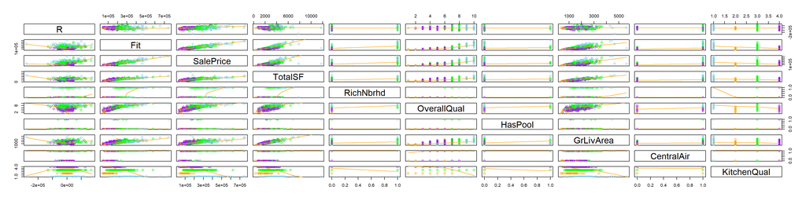

```r
palette(c("skyblue","orange","green","purple","steelblue","red","green3","black"))
pairs(
  cbind(
    R = mylm7$res,
    Fit = mylm7$fit,
    train %>% select(
      SalePrice,
      TotalSF,
      RichNbrhd,
      OverallQual,
      HasPool,
      GrLivArea,
      CentralAir,
      KitchenQual
      )
    ),
  panel = panel.smooth,
  col = train$KitchenQual
)
```

```r
mylm8 <- lm(SalePrice ~ TotalSF * RichNbrhd * OverallQual * HasPool * GrLivArea * CentralAir * KitchenQual * I(TotalSF^2), data = train)
summary(mylm8)
```

```
##
## Call:
## lm(formula = SalePrice ~ TotalSF * RichNbrhd * OverallQual *
##     HasPool * GrLivArea * CentralAir * KitchenQual * I(TotalSF^2),
##     data = train)
##
## Residuals:
##     Min      1Q  Median      3Q     Max
## -144677  -13466      40   13233  166542
##
## Coefficients: (369 not defined because of singularities)
##                                                                                         Estimate
## (Intercept)                                                                            1.371e+06
## TotalSF                                                                                6.419e+02
## RichNbrhd                                                                             -1.549e+08
## OverallQual                                                                           -5.055e+05
## HasPool                                                                                4.004e+07
## GrLivArea                                                                             -7.356e+02
## CentralAir                                                                            -1.226e+05
## KitchenQualFa                                                                         -1.157e+06
## KitchenQualGd                                                                         -1.665e+06
## KitchenQualTA                                                                         -1.784e+06
## I(TotalSF^2)                                                                          -9.443e-01
## TotalSF:RichNbrhd                                                                      1.236e+05
## TotalSF:OverallQual                                                                    2.155e+02
## RichNbrhd:OverallQual                                                                  1.558e+07
## TotalSF:HasPool                                                                       -7.697e+01
## RichNbrhd:HasPool                                                                     -3.917e+07
## OverallQual:HasPool                                                                   -8.619e+04
## TotalSF:GrLivArea                                                                     -7.214e-01
## RichNbrhd:GrLivArea                                                                    7.873e+04
## OverallQual:GrLivArea                                                                  2.700e+02
## HasPool:GrLivArea                                                                      1.053e+02
## TotalSF:CentralAir                                                                    -1.158e+02
## RichNbrhd:CentralAir                                                                          NA
## OverallQual:CentralAir                                                                -3.636e+04
## HasPool:CentralAir                                                                            NA
## GrLivArea:CentralAir                                                                   2.461e+02
## TotalSF:KitchenQualFa                                                                 -1.212e+03
## TotalSF:KitchenQualGd                                                                  4.341e+02
```

[output cut: 2527 more lines]

```
## TotalSF:OverallQual:HasPool:GrLivArea:CentralAir:KitchenQualFa:I(TotalSF^2)
## TotalSF:OverallQual:HasPool:GrLivArea:CentralAir:KitchenQualGd:I(TotalSF^2)
## TotalSF:OverallQual:HasPool:GrLivArea:CentralAir:KitchenQualTA:I(TotalSF^2)
## RichNbrhd:OverallQual:HasPool:GrLivArea:CentralAir:KitchenQualFa:I(TotalSF^2)
## RichNbrhd:OverallQual:HasPool:GrLivArea:CentralAir:KitchenQualGd:I(TotalSF^2)
## RichNbrhd:OverallQual:HasPool:GrLivArea:CentralAir:KitchenQualTA:I(TotalSF^2)
## TotalSF:RichNbrhd:OverallQual:HasPool:GrLivArea:CentralAir:KitchenQualFa:I(TotalSF^2)
## TotalSF:RichNbrhd:OverallQual:HasPool:GrLivArea:CentralAir:KitchenQualGd:I(TotalSF^2)
## TotalSF:RichNbrhd:OverallQual:HasPool:GrLivArea:CentralAir:KitchenQualTA:I(TotalSF^2)
## ---
## Signif. codes:  0 '***' 0.001 '**' 0.01 '*' 0.05 '.' 0.1 ' ' 1
##
## Residual standard error: 26550 on 1317 degrees of freedom
## Multiple R-squared:  0.8992, Adjusted R-squared:  0.8883
## F-statistic: 82.75 on 142 and 1317 DF,  p-value: < 2.2e-16
```

```r
mylm9 <- lm(SalePrice ~ (TotalSF + RichNbrhd + OverallQual + HasPool + GrLivArea + CentralAir + KitchenQual + I(TotalSF^2) + TotalSF:RichNbrhd + RichNbrhd:OverallQual + RichNbrhd:HasPool + OverallQual:HasPool + RichNbrhd:GrLivArea + RichNbrhd:KitchenQual + HasPool:KitchenQual + TotalSF:CentralAir:KitchenQual + GrLivArea:CentralAir:KitchenQual + RichNbrhd:I(TotalSF^2) + TotalSF:RichNbrhd:OverallQual + TotalSF:RichNbrhd:GrLivArea + RichNbrhd:OverallQual:GrLivArea + TotalSF:RichNbrhd:I(TotalSF^2) + RichNbrhd:OverallQual:I(TotalSF^2) + RichNbrhd:GrLivArea:I(TotalSF^2) + RichNbrhd:GrLivArea:KitchenQual + TotalSF:RichNbrhd:OverallQual:GrLivArea + TotalSF:RichNbrhd:GrLivArea:KitchenQual + RichNbrhd:OverallQual:GrLivArea:KitchenQual), data = train)
summary(mylm9)
```

```
##
## Call:
## lm(formula = SalePrice ~ (TotalSF + RichNbrhd + OverallQual +
##     HasPool + GrLivArea + CentralAir + KitchenQual + I(TotalSF^2) +
##     TotalSF:RichNbrhd + RichNbrhd:OverallQual + RichNbrhd:HasPool +
##     OverallQual:HasPool + RichNbrhd:GrLivArea + RichNbrhd:KitchenQual +
##     HasPool:KitchenQual + TotalSF:CentralAir:KitchenQual + GrLivArea:CentralAir:KitchenQual +
##     RichNbrhd:I(TotalSF^2) + TotalSF:RichNbrhd:OverallQual +
##     TotalSF:RichNbrhd:GrLivArea + RichNbrhd:OverallQual:GrLivArea +
##     TotalSF:RichNbrhd:I(TotalSF^2) + RichNbrhd:OverallQual:I(TotalSF^2) +
##     RichNbrhd:GrLivArea:I(TotalSF^2) + RichNbrhd:GrLivArea:KitchenQual +
##     TotalSF:RichNbrhd:OverallQual:GrLivArea + TotalSF:RichNbrhd:GrLivArea:KitchenQual +
##     RichNbrhd:OverallQual:GrLivArea:KitchenQual), data = train)
##
## Residuals:
##     Min      1Q  Median      3Q     Max
## -176516  -16030    1040   13707  164424
##
## Coefficients: (7 not defined because of singularities)
##                                                 Estimate Std. Error t value
## (Intercept)                                   -1.037e+03  2.053e+04  -0.051
## TotalSF                                        3.393e+01  9.311e+00   3.644
## RichNbrhd                                      3.513e+05  4.585e+05   0.766
## OverallQual                                    1.532e+04  9.573e+02  15.999
## HasPool                                        4.650e+05  1.916e+05   2.427
## GrLivArea                                      2.292e+01  1.180e+01   1.943
## CentralAir                                    -1.554e+04  9.982e+03  -1.557
## KitchenQualFa                                 -3.523e+04  1.714e+04  -2.056
## KitchenQualGd                                 -6.628e+04  1.576e+04  -4.205
## KitchenQualTA                                 -3.989e+04  1.572e+04  -2.538
## I(TotalSF^2)                                  -5.162e-03  1.046e-03  -4.937
## TotalSF:RichNbrhd                             -4.557e+02  3.221e+02  -1.415
## RichNbrhd:OverallQual                         -9.594e+04  6.647e+04  -1.444
## RichNbrhd:HasPool                              1.455e+04  9.138e+04   0.159
## OverallQual:HasPool                           -5.292e+04  1.778e+04  -2.976
## RichNbrhd:GrLivArea                            6.790e+02  4.262e+02   1.593
## RichNbrhd:KitchenQualFa                               NA         NA      NA
## RichNbrhd:KitchenQualGd                        1.121e+05  5.812e+04   1.929
## RichNbrhd:KitchenQualTA                       -3.136e+05  4.608e+05  -0.681
## HasPool:KitchenQualFa                                 NA         NA      NA
```

[output cut: 66 more lines]

```
## RichNbrhd:GrLivArea:KitchenQualGd             0.088896 .
## RichNbrhd:GrLivArea:KitchenQualTA             0.468616
## TotalSF:RichNbrhd:OverallQual:GrLivArea       0.184898
## TotalSF:RichNbrhd:GrLivArea:KitchenQualFa           NA
## TotalSF:RichNbrhd:GrLivArea:KitchenQualGd     0.605956
## TotalSF:RichNbrhd:GrLivArea:KitchenQualTA           NA
## RichNbrhd:OverallQual:GrLivArea:KitchenQualFa       NA
## RichNbrhd:OverallQual:GrLivArea:KitchenQualGd 0.077013 .
## RichNbrhd:OverallQual:GrLivArea:KitchenQualTA       NA
## ---
## Signif. codes:  0 '***' 0.001 '**' 0.01 '*' 0.05 '.' 0.1 ' ' 1
##
## Residual standard error: 29220 on 1420 degrees of freedom
## Multiple R-squared:  0.8683, Adjusted R-squared:  0.8647
## F-statistic: 240.1 on 39 and 1420 DF,  p-value: < 2.2e-16
```

### Final Model Summary

```r
lmfinal <- lm(SalePrice ~ TotalSF + OverallQual + RichQual + RichGrLvArea  + KitchenQual + TotalSF:OverallQual  + RichNbrhd:HasPool + I(TotalSF^2) + TotalSF:RichGrLivAreaKitchenGd  + TotalSF:OverallQual:RichGrLivAreaKitchenGd + KitchenAbvGr + NoAlley, data = train)
summary(lmfinal)
```

```
##
## Call:
## lm(formula = SalePrice ~ TotalSF + OverallQual + RichQual + RichGrLvArea +
##     KitchenQual + TotalSF:OverallQual + RichNbrhd:HasPool + I(TotalSF^2) +
##     TotalSF:RichGrLivAreaKitchenGd + TotalSF:OverallQual:RichGrLivAreaKitchenGd +
##     KitchenAbvGr + NoAlley, data = train)
##
## Residuals:
##     Min      1Q  Median      3Q     Max
## -261483  -15909    -137   15048  178212
##
## Coefficients:
##                                              Estimate Std. Error t value
## (Intercept)                                 9.789e+04  1.303e+04   7.511
## TotalSF                                     3.030e+01  4.179e+00   7.252
## OverallQual                                -1.478e+04  2.511e+03  -5.885
## RichQual                                   -1.202e+04  1.412e+03  -8.514
## RichGrLvArea                                7.172e+01  6.114e+00  11.732
## KitchenQualFa                              -4.414e+04  6.745e+03  -6.544
## KitchenQualGd                              -1.443e+04  4.434e+03  -3.254
## KitchenQualTA                              -3.097e+04  4.713e+03  -6.571
## I(TotalSF^2)                               -1.149e-02  6.005e-04 -19.131
## KitchenAbvGr                               -1.538e+04  3.706e+03  -4.150
## NoAlley                                     1.246e+04  3.232e+03   3.855
## TotalSF:OverallQual                         1.233e+01  9.384e-01  13.144
## RichNbrhd:HasPool                           8.377e+04  3.278e+04   2.555
## TotalSF:RichGrLivAreaKitchenGd             -2.048e-02  4.385e-03  -4.671
## TotalSF:OverallQual:RichGrLivAreaKitchenGd  2.091e-03  5.201e-04   4.021
##                                            Pr(>|t|)
## (Intercept)                                1.03e-13 ***
## TotalSF                                    6.69e-13 ***
## OverallQual                                4.95e-09 ***
## RichQual                                    < 2e-16 ***
## RichGrLvArea                                < 2e-16 ***
## KitchenQualFa                              8.30e-11 ***
## KitchenQualGd                              0.001163 **
## KitchenQualTA                              6.96e-11 ***
## I(TotalSF^2)                                < 2e-16 ***
## KitchenAbvGr                               3.52e-05 ***
## NoAlley                                    0.000121 ***
## TotalSF:OverallQual                         < 2e-16 ***
## RichNbrhd:HasPool                          0.010708 *
## TotalSF:RichGrLivAreaKitchenGd             3.28e-06 ***
## TotalSF:OverallQual:RichGrLivAreaKitchenGd 6.11e-05 ***
## ---
## Signif. codes:  0 '***' 0.001 '**' 0.01 '*' 0.05 '.' 0.1 ' ' 1
##
## Residual standard error: 29580 on 1445 degrees of freedom
## Multiple R-squared:  0.8627, Adjusted R-squared:  0.8614
## F-statistic: 648.4 on 14 and 1445 DF,  p-value: < 2.2e-16
```

```r
b <- coef(lmfinal)
b
```

```
##                                (Intercept)
##                               9.788813e+04
##                                    TotalSF
##                               3.030139e+01
##                                OverallQual
##                              -1.477850e+04
##                                   RichQual
##                              -1.202407e+04
##                               RichGrLvArea
##                               7.172174e+01
##                              KitchenQualFa
##                              -4.413642e+04
##                              KitchenQualGd
##                              -1.442850e+04
##                              KitchenQualTA
##                              -3.096978e+04
##                               I(TotalSF^2)
##                              -1.148874e-02
##                               KitchenAbvGr
##                              -1.537800e+04
##                                    NoAlley
##                               1.246076e+04
##                        TotalSF:OverallQual
##                               1.233374e+01
##                          RichNbrhd:HasPool
##                               8.377094e+04
##             TotalSF:RichGrLivAreaKitchenGd
##                              -2.047968e-02
## TotalSF:OverallQual:RichGrLivAreaKitchenGd
##                               2.091242e-03
```

# Final Model

## Mathematical Model

$$Y_i = \beta_0 + \beta_1 X_{TotalSF_i} + \beta_2 X_{OverallQual_i} +
\beta_3 X_{RichQual_i} + \beta_4 X_{RichGrLvArea_i} +\\
\beta_5 X_{KitchenQualFa_i} + \beta_6 X_{KitchenQualGd_i} + \beta_7
X_{KitchenQualTA_i} + \beta_8 X_{TotalSF_i}^2 + \beta_9
X_{KitchenAbvGr_i} +\\
\beta_{10} X_{NoAlley} + \beta_{11} X_{TotalSF_i} X_{OverallQual_i} +
\beta_{12} X_{RichNbrhd_i} X_{HasPool_i} + \beta_{13} X_{TotalSF_i}
X_{RichGrLivAreaKitchenGd_i} +\\
\beta_{14} X_{TotalSF_i} X_{OverallQual_i} X_{RichGrLivAreaKitchenGd_i}
+ \epsilon_i$$

## Graphical Representation of Model

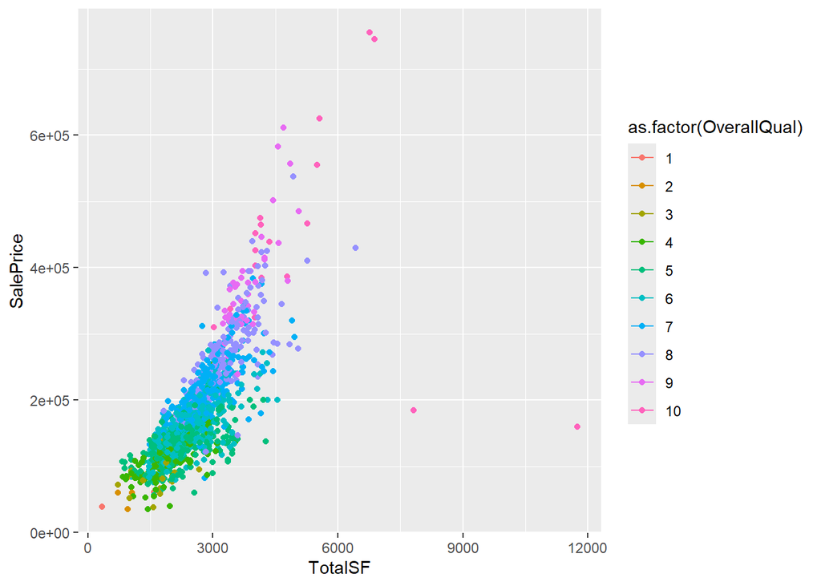

```r
ggplot(
  train,
  aes(
    x = TotalSF,
    y = SalePrice,
    color = as.factor(OverallQual)
  )
)+
  geom_point()+
  stat_function(
    fun = function(TotalSF, OverallQual, RichQual, RichGrLvArea, KitchenQualFa = 0, KitchenQualGd = 0, KitchenQualTA = 0, KitchenAbvGr, NoAlley, RichNbrhd, HasPool, RichGrLivAreaKitchenGd){
      b[1]+ b[2]*TotalSF + b[3]*OverallQual + b[4]*RichQual + b[5]*RichGrLvArea + b[6]*KitchenQualFa + b[7]*KitchenQualGd + b[8]*KitchenQualTA + b[9]*I(TotalSF^2) + b[10]*KitchenAbvGr + b[11]*NoAlley + b[12]*TotalSF:OverallQual + b[13]*RichNbrhd:HasPool + b[14]*TotalSF:RichGrLivAreaKitchenGd + b[15]*TotalSF:OverallQual:RichGrLivAreaKitchenGd
    }
  )
```

```r
  facet_wrap(~as.factor(OverallQual))
```

[output not shown]

## Model Validation

```r
test <- read.csv('../../data/house_selling_prices_data/test.csv', stringsAsFactors = TRUE)
```

```r
# mutate test to be the same as train
# we will do a lot of mutating this week
test <- test %>%

  #fix NA in alley
  mutate(
    Alley = as.character(Alley),
    Alley = replace_na(Alley, 'None'),
    Alley = as.factor(Alley)
  ) %>%

  #fix None in MasVnr Type
  mutate(
    MasVnrType = as.character(MasVnrType),
    MasVnrType = replace(MasVnrType, (MasVnrType == 'None') | is.na(MasVnrType), 'NoVNR'),
    MasVnrType = as.factor(MasVnrType)
  ) %>%

  # fix basement stuff
  mutate(
    BsmtQual = as.character(BsmtQual),
    BsmtQual = replace_na(BsmtQual, 'Nb'),
    BsmtQual = as.factor(BsmtQual),

    BsmtCond = as.character(BsmtCond),
    BsmtCond = replace_na(BsmtCond, 'Nb'),
    BsmtCond = as.factor(BsmtCond),

    BsmtExposure = as.character(BsmtExposure),
    BsmtExposure = replace_na(BsmtExposure, 'Nb'),
    BsmtExposure = as.factor(BsmtExposure),

    BsmtFinType1 = as.character(BsmtFinType1),
    BsmtFinType1 = replace_na(BsmtFinType1, 'Nb'),
    BsmtFinType1 = as.factor(BsmtFinType1),

    BsmtFinType2 = as.character(BsmtFinType2),
    BsmtFinType2 = replace_na(BsmtFinType2, 'Nb'),
    BsmtFinType2 = as.factor(BsmtFinType2)
  ) %>%

  #fix electrical
  mutate(
    Electrical = as.character(Electrical),
    Electrical = replace_na(Electrical, 'NoElec'),
  ) %>%

  # fix Fireplacequal
  mutate(
    FireplaceQu = as.character(FireplaceQu),
    FireplaceQu = replace_na(FireplaceQu, 'NoFP'),
    FireplaceQu = as.factor(FireplaceQu)
  ) %>%

  # fix garage stuff
  mutate(
    GarageType = as.character(GarageType),
    GarageType = replace_na(GarageType, 'NoGar'),
    GarageType = as.factor(GarageType),

    GarageFinish = as.character(GarageFinish),
    GarageFinish = replace_na(GarageFinish, 'NoGar'),
    GarageFinish = as.factor(GarageFinish),

    GarageQual = as.character(GarageQual),
    GarageQual = replace_na(GarageQual, 'NoGar'),
    GarageQual = as.factor(GarageQual),

    GarageCond = as.character(GarageCond),
    GarageCond = replace_na(GarageCond, 'NoGar'),
    GarageCond = as.factor(GarageCond)

  ) %>%

  #fix poolqc
  mutate(
    PoolQC = as.character(PoolQC),
    PoolQC = replace_na(PoolQC, 'NoPool'),
    PoolQC = as.factor(PoolQC)
  ) %>%

  # fix fence
  mutate(
    Fence = as.character(Fence),
    Fence = replace_na(Fence, 'NoFence'),
    Fence = as.factor(Fence)
  ) %>%

  # MiscFeature
  mutate(
    MiscFeature = as.character(MiscFeature),
    MiscFeature = replace_na(MiscFeature, 'NoMiscFt'),
    MiscFeature = as.factor(MiscFeature)
  )


test <- test %>%
  mutate(
    TotalSF = X1stFlrSF + X2ndFlrSF + TotalBsmtSF,
    RichNbrhd = case_when(
      Neighborhood %in% c("StoneBr", "NridgHt", "NoRidge") ~ 1,
      TRUE ~ 0
    )
  )



test <- test %>%
  mutate(
    NewConst = case_when(
      SaleType == 'New' ~ 1,
      TRUE ~ 0
    ),
    WDSale = case_when(
      SaleType == 'WD' ~ 1,
      TRUE ~ 0
    ),
    FifteenDown = case_when(
      SaleType == 'Con' ~ 1,
      TRUE ~ 0
    ),
    HasPool = case_when(
      PoolArea > 0 ~ 1,
      TRUE ~ 0
    ),
    HasGarage = case_when(
      GarageQual == 'NoGar' ~ 0,
      TRUE ~ 1
    ),
    GoodKitchen = case_when(
      KitchenQual  %in% c('Ex', 'Gd', 'TA') ~ 1,
      TRUE ~ 0
    ),

    #capture interaction between overall quality and rich neighborhood
    RichQual = OverallQual * RichNbrhd,

    #capture interaction between living area above grade and rich neighborhood
    RichGrLvArea = GrLivArea * RichNbrhd,

    #capture overall quality and pool
    OverallQualPool = OverallQual * HasPool,
    RichGrLivAreaKitchenGd = RichNbrhd * GrLivArea * (KitchenQual == "Gd"),

    #convert central air to binary
    CentralAir = case_when(
      CentralAir == 'Y' ~ 1,
      TRUE ~ 0
    ),
    NoAlley = case_when(
      Alley == 'None' ~ 1,
      TRUE ~ 0
    )
  )
```

```r
# set.seed(101)
#
#
# lmfinal <- lm(SalePrice ~ TotalSF + RichNbrhd + OverallQual + RichQual + RichGrLvArea + HasPool + CentralAir + KitchenQual + TotalSF:HasPool + TotalSF:OverallQual  + RichNbrhd:HasPool + I(TotalSF^2) + TotalSF:RichGrLivAreaKitchenGd + OverallQual:RichGrLivAreaKitchenGd  + TotalSF:OverallQual:RichGrLivAreaKitchenGd + KitchenAbvGr, data = train)
# summary(lmfinal)
#
# pred <- predict(lmfinal, test)
```

```r
set.seed(121)

num_rows <- 600 #1460 total
keep <- sample(1:nrow(train), num_rows)

mytrain <- train[keep, ] #Use this in the lm(..., data=mytrain)

mytest <- train[-keep, ] #Use this in the predict(..., newdata=mytest)


lmfinaltrain <- lm(SalePrice ~ TotalSF + OverallQual + RichQual + RichGrLvArea  + KitchenQual + TotalSF:OverallQual  + RichNbrhd:HasPool + I(TotalSF^2) + TotalSF:RichGrLivAreaKitchenGd  + TotalSF:OverallQual:RichGrLivAreaKitchenGd + KitchenAbvGr + NoAlley, data = mytrain)

pred <- predict(lmfinaltrain, newdata = mytest)


# get y bar for the test data
ybar <- mean(mytest$SalePrice)

# get SSTO for the test data
SSTO <- sum((mytest$SalePrice - ybar)^2)

#get SSE for each model
SSE <- sum((mytest$SalePrice - pred)^2)

# get the adjusted r squared for each model
n <- length(mytest$SalePrice)
param_num <- length(coef(lmfinaltrain))
adjrs <- 1 - (n-1)/(n-param_num) * (SSE/SSTO)
adjrs
```

```
## [1] 0.8303527
```

## Summary of Metrics

It should be noted that an extremely basic XGBoost regression model achieved a validation R-Squared of $0.9117$. This is in part due to my own shortcomings in designing a linear model in r, and also to the fact that machine learning models have the ability to find extremely detailed interactions in a fraction of the time that I spent on my model.